# Modelo para detección de anomalias

#### Realizado por Sergio Alejandro Díaz Gutierrez

- Se le ha solicitado detectar clientes atípicos que se cree pueden estar involucrados en comportamientos delictivos asociados a lavado de activos, para iniciar una investigación sobre ellos.
- Se le ha solicitado a usted construir un pipeline para la detección de anomalías en este conjunto de clientes.

# Supuestos

- Se asume que las transacciones atipicas pueden significar actividades delictivas asociadas con el lavado de activos.
- Se presume que las transacciones sospechosas pueden estar relacionadas con montos inusuales.
- Se considera que los datos proporcionados son representativos y completos para el análisis de detección de anomalías.

# Marco Teórico

#### La detección de anomalías en datos financieros es un problema común en la industria financiera, el cual puede ser abordado utilizando técnicas de aprendizaje automático y estadística.

#### Para esto caso utilizaremos, Isolation Forest: Es un algoritmo de aprendizaje no supervisado que se basa en la construcción de múltiples árboles de decisión para aislar las anomalías en los datos. Identifica las anomalías como muestras que son menos frecuentes y más difíciles de aislar en comparación con las muestras normales.

# Exploración y tratamiento de datos.

#### Realizamos el cargue inicial de los datos (Transacciones.csv). Se realiza un pequeño análisis donde observamos valores inconsistentes en la data, realizamos la limpieza de dichas inconsistencias tanto en datos categóricos como numéricos.

#### Luego realizamos de las variables que usan para crear el modelo de detección de anomalías. Una vez extraídas las variables, procedemos a convertir los datos categóricos a numéricos para poder realizar la normalización de la información.

```python
## Importar librerías
import numpy as np
import pandas as pd
import matplotlib.pyplot as plt
import seaborn as sns

import warnings
warnings.filterwarnings('ignore')
```

```python
# Funciones
def importDatos(ruta, archivo, ext, sepa):
  if ext == '.csv':
    data = pd.read_csv(ruta+archivo+ext, sep= sepa, encoding='latin-1')
    return data
  elif ext == '.xlsx':
    data = pd.read_excel(ruta+archivo+ext)
    return data
  else:
    print('Extension diferente')

def datos_NAN(df):
    if isinstance(df, pd.DataFrame):
        total_na = df.isna().sum().sum()
        print("Dimesiones: %d filas, %d columnas" % (df.shape[0], df.shape[1]))
        print("Total de Valores NAN: %d" % (total_na))
        print("%40s %10s  %10s %10s" % ("Nombre Columna", "Tipo Dato", "#Unicos", "Cant Valores NAN"))
        col_name = df.columns
        dtyp = df.dtypes
        uniq = df.nunique()
        na_val = df.isna().sum()
        for i in range(len(df.columns)):
            print("%40s %10s  %10s %10s" % (col_name[i], dtyp[i], uniq[i], na_val[i]))
    else:
        print("Se esperaba un dataframe: %15s" % (type(df)))

# Función para reemplazo de valores numéricos con la mediana
def imputacionNa(df, nomCol, param):
    if param == 'media':
        df[nomCol] = df[nomCol].fillna(df[nomCol].mean())
        return df[nomCol]
    else:
        df[nomCol] = df[nomCol].fillna(df[nomCol].median())
        return df[nomCol]

# Función para reeemplazo NA categóricos
def imputacionCatNa(df, nomCol):
    df[nomCol] = df[nomCol].fillna(df[nomCol].mode()[0])
    return df[nomCol]

# Funcion para revisar datos categóricos o texto
def revCategoricos(df, nomCol):
    rev = df[nomCol].value_counts()
    return rev

def dispersion (df, cruce, num, numdos):
    g = sns.FacetGrid(df, hue=cruce, palette='flare', height=5)
    g.map(sns.scatterplot, num, numdos, s=100, alpha=0.5)
    g.add_legend()
    return g

##Función multigraficas
def multigraf (df, coluno, coldos):
    g = sns.FacetGrid(df, col=coluno)
    g.map(sns.histplot, coldos)
    return g

# Función para datos categóricos modificaciones
def imputacionCat(df, nomCol, busqueda, reempl):
    df[nomCol] = np.where(df[nomCol] == busqueda, reempl, df[nomCol])
    return df[nomCol]

from sklearn.preprocessing import MinMaxScaler
def normaData(df):
    valores = df.values
    scaler = MinMaxScaler(feature_range=(0, 1))
    scaler = scaler.fit(valores)

    pd.DataFrame(np.vstack((scaler.data_min_, scaler.data_max_)),
             index=['Min', 'Max'],
             columns=df.columns)

    normalizados = scaler.transform(valores)
    df_norm = pd.DataFrame(normalizados,
                       index=df.index,
                       columns=df.columns)
    return df_norm
```

## Análisis inicial

```python
# Cargue de la información
data = importDatos('./Dataset/','TRANSACCIONES','.csv',';')

data
```

|  | IdCliente | PARTY_TYPE_DESC | PARTY_DATE_OF_BIRTH | FECHA_EXPEDICION_DOCUMENTO | CUSTOMER_SINCE_DATE | GENDER_CODE | INGRESOS_SAS | STREET_STATE_NAME | STREET_STATE_CODE | OCCUPATION_DESC | ... | TOT_REDESCUENTOS | TOT_TRANSACH | TOT_DEPOSITOS | TOT_DESEMB | TOT_PAGO_CRED | TOT_PAGO_TC | TOT_RETIROS | TOT_PAGO_CREDITOS | TOT_INT_RECIBIDAS | TOT_INT_ENVIADAS |
| --- | --- | --- | --- | --- | --- | --- | --- | --- | --- | --- | --- | --- | --- | --- | --- | --- | --- | --- | --- | --- | --- |
| 0 | 120 | INDIVIDUAL | 24APR01:00:00:00 | 03MAY19:00:00:00 | 02AUG22:00:00:00 | M | 1800000 | DISTRITO CAPITAL | 11001.0 | EMPLEADO | ... | 0 | 577153.47 | 0 | 0.0 | 0.0 | 0.0 | 187000.0 | 0.0 | 0 | 0.0 |
| 1 | 184 | INDIVIDUAL | 11JUL01:00:00:00 | 11SEP19:00:00:00 | 26MAY22:00:00:00 | F | 800000 | DISTRITO CAPITAL | 11001.0 | EMPLEADO | ... | 0 | 0.0 | 0 | 0.0 | 0.0 | 0.0 | 507000.0 | 0.0 | 0 | 0.0 |
| 2 | 198 | INDIVIDUAL | 14JAN01:00:00:00 | 23SEP19:00:00:00 | 12JAN23:00:00:00 | M | 1200000 | CUNDINAMARCA | 25754.0 | EMPLEADO | ... | 0 | 0.0 | 0 | 0.0 | 0.0 | 0.0 | 0.0 | 0.0 | 0 | 0.0 |
| 3 | 431 | INDIVIDUAL | 10NOV01:00:00:00 | 26NOV19:00:00:00 | 25NOV20:00:00:00 | M | 1700000 | DISTRITO CAPITAL | 11001.0 | EMPLEADO | ... | 0 | 0.0 | 0 | 0.0 | 0.0 | 0.0 | 0.0 | 0.0 | 0 | 0.0 |
| 4 | 597 | INDIVIDUAL | 19MAR01:00:00:00 | 08APR19:00:00:00 | 20MAY21:00:00:00 | M | 18000000 | CUNDINAMARCA | 25754.0 | EMPLEADO | ... | 0 | 2283910.0 | 0 | 0.0 | 99000.0 | 0.0 | 2126550.0 | 99000.0 | 0 | 0.0 |
| ... | ... | ... | ... | ... | ... | ... | ... | ... | ... | ... | ... | ... | ... | ... | ... | ... | ... | ... | ... | ... | ... |
| 72159 | 7215519 | INDIVIDUAL | 16AUG00:00:00:00 | 26APR22:00:00:00 | 14MAR23:00:00:00 | F | 1500000 | VALLE | 76001.0 | EMPLEADO | ... | 0 | 0 | 0.0 | 0.0 | 0.0 | 0.0 | 1177900.0 | 0.0 | 0 | 0.0 |
| 72160 | 7215592 | INDIVIDUAL | 23MAY76:00:00:00 | 26MAY22:00:00:00 | 14FEB23:00:00:00 | M | 1260640 | DISTRITO CAPITAL | 11001.0 | EMPLEADO | ... | 0 | 0 | 0.0 | 0.0 | 0.0 | 0.0 | 0.0 | 0.0 | 0 | 0.0 |
| 72161 | 7215930 | INDIVIDUAL | 25NOV84:00:00:00 | 13JUN22:00:00:00 | 15FEB23:00:00:00 | M | 2000000 | SANTANDER | 68001.0 | EMPLEADO | ... | 0 | 0 | 0.0 | 0.0 | 0.0 | 0.0 | 810000.0 | 0.0 | 0 | 0.0 |
| 72162 | 7216031 | INDIVIDUAL | 09MAY95:00:00:00 | 21FEB23:00:00:00 | 04APR23:00:00:00 | O | 0 | NaN | NaN | NaN | ... | 0 | 0 | 0.0 | 0.0 | 0.0 | 0.0 | 4840.0 | 0.0 | 0 | 0.0 |
| 72163 | 7216390 | INDIVIDUAL | 11MAR96:00:00:00 | 06APR22:00:00:00 | 17APR23:00:00:00 | M | 1160000 | VALLE | 76130.0 | EMPLEADO | ... | 0 | 0 | 0.0 | 0.0 | 0.0 | 0.0 | 490000.0 | 0.0 | 0 | 0.0 |

72164 rows × 51 columns

```python
# Revisión de valores NAN
datos_NAN(data)
```

```
Dimesiones: 72164 filas, 51 columnas
Total de Valores NAN: 23580
                          Nombre Columna  Tipo Dato     #Unicos Cant Valores NAN
                               IdCliente      int64       72164          0
                         PARTY_TYPE_DESC     object           2          0
                     PARTY_DATE_OF_BIRTH     object       21927          0
              FECHA_EXPEDICION_DOCUMENTO     object       13163          0
                     CUSTOMER_SINCE_DATE     object        9895          0
                             GENDER_CODE     object           4       2048
                            INGRESOS_SAS     object       16226          0
                       STREET_STATE_NAME     object          31       1761
                       STREET_STATE_CODE    float64         864       1743
                         OCCUPATION_DESC     object          10       3591
                           INDUSTRY_CODE      int64         468          0
                               PROFESION     object         306       9866
                           ORIGEN_FONDOS     object        8800       4571
                                 TOT_TXN     object       41985          0
                                  NO_TXN      int64         303          0
                                  TOT_CR     object       38002          0
                                 CANT_CR      int64         165          0
                                  TOT_DB     object       31462          0
                                 CANT_DB      int64         224          0
                                  TOT_PD     object        1373          0
                                 CANT_PD      int64          34          0
                                 TOT_CHE    float64         361          0
                                CANT_CHE      int64          25          0
                                 TOT_EFE    float64        3018          0
                                CANT_EFE      int64          74          0
                                 TOT_ELE     object       40215          0
                                CANT_ELE      int64         290          0
                                 TOT_IND     object        4397          0
                                CANT_IND      int64          36          0
                           TOT_CONS_FIJO    float64        3976          0
                            TOT_CONS_ROT     object        1003          0
                          TOT_CONS_VEHIC    float64         359          0
                                TOT_CORR     object        1171          0
                                 TOT_AHO     object       31358          0
                                 TOT_REM      int64           1          0
                         TOT_TC_COMECIAL    float64         321          0
                          TOT_TC_CONSUMO    float64       11825          0
                            TOT_VIVIENDA    float64        1469          0
                         TOT_VIV_LEASING    float64         592          0
                           TOT_DAVIPLATA    float64         681          0
                           TOT_ORDINARIA    float64         209          0
                        TOT_REDESCUENTOS      int64          15          0
                            TOT_TRANSACH     object        7660          0
                           TOT_DEPOSITOS     object        3334          0
                              TOT_DESEMB    float64        7142          0
                           TOT_PAGO_CRED    float64        6021          0
                             TOT_PAGO_TC    float64        7568          0
                             TOT_RETIROS    float64       18488          0
                       TOT_PAGO_CREDITOS    float64       11653          0
                       TOT_INT_RECIBIDAS      int64           1          0
                        TOT_INT_ENVIADAS    float64          64          0
```

```python
# Limpieza de valores NAN en las columnas categoricas 'GENDER_CODE' 'STREET_STATE_NAME' 'STREET_STATE_CODE' 'OCCUPATION_DESC' 'PROFESION' 'ORIGEN_FONDOS' 'TOT_DEPOSITOS'
data['GENDER_CODE'] = imputacionCatNa(data, 'GENDER_CODE')
data['STREET_STATE_NAME'] = imputacionCatNa(data, 'STREET_STATE_NAME')
data['STREET_STATE_CODE'] = imputacionCatNa(data, 'STREET_STATE_CODE')
data['OCCUPATION_DESC'] = imputacionCatNa(data, 'OCCUPATION_DESC')
data['PROFESION'] = imputacionCatNa(data, 'PROFESION')
data['ORIGEN_FONDOS'] = imputacionCatNa(data, 'ORIGEN_FONDOS')
data['TOT_DEPOSITOS'] = imputacionCatNa(data, 'TOT_DEPOSITOS')
data['TOT_TRANSACH'] = imputacionCatNa(data, 'TOT_TRANSACH')
```

```python
# Limpieza de valores NAN en las columnas numéricas 'TOT_VIVIENDA' 'TOT_VIV_LEASING' 'TOT_DAVIPLATA' 'TOT_ORDINARIA' 'TOT_REDESCUENTOS' 'TOT_TRANSACH' 'TOT_DESEMB' 'TOT_PAGO_CRED' 'TOT_PAGO_TC' 'TOT_RETIROS' 'TOT_PAGO_CREDITOS' 'TOT_INT_RECIBIDAS' 'TOT_INT_ENVIADAS'
data['TOT_VIVIENDA'] = imputacionNa(data, 'TOT_VIVIENDA', 'Mediana')
data['TOT_VIV_LEASING'] = imputacionNa(data, 'TOT_VIV_LEASING', 'Mediana')
data['TOT_DAVIPLATA'] = imputacionNa(data, 'TOT_DAVIPLATA', 'Mediana')
data['TOT_ORDINARIA'] = imputacionNa(data, 'TOT_ORDINARIA', 'Mediana')
data['TOT_REDESCUENTOS'] = imputacionNa(data, 'TOT_REDESCUENTOS', 'Mediana')
data['TOT_DESEMB'] = imputacionNa(data, 'TOT_DESEMB', 'Mediana')
data['TOT_PAGO_CRED'] = imputacionNa(data, 'TOT_PAGO_CRED', 'Mediana')
data['TOT_PAGO_TC'] = imputacionNa(data, 'TOT_PAGO_TC', 'Mediana')
data['TOT_RETIROS'] = imputacionNa(data, 'TOT_RETIROS', 'Mediana')
data['TOT_PAGO_CREDITOS'] = imputacionNa(data, 'TOT_PAGO_CREDITOS', 'Mediana')
data['TOT_INT_RECIBIDAS'] = imputacionNa(data, 'TOT_INT_RECIBIDAS', 'Mediana')
data['TOT_INT_ENVIADAS'] = imputacionNa(data, 'TOT_INT_ENVIADAS', 'Mediana')
```

```python
# Imputación del dato categorico 0 en 'GENDER_ CODE'
data.GENDER_CODE = imputacionCat(data, 'GENDER_CODE', '0','O')
# Imputación del dato categorico N en 'OCCUPATION_DESC'
data.OCCUPATION_DESC = imputacionCat(data, 'OCCUPATION_DESC', 'N','NO TIENE')
```

```python
# Revisión de datos NAN después de la limpieza
datos_NAN(data)
```

```
Dimesiones: 72164 filas, 51 columnas
Total de Valores NAN: 0
                          Nombre Columna  Tipo Dato     #Unicos Cant Valores NAN
                               IdCliente      int64       72164          0
                         PARTY_TYPE_DESC     object           2          0
                     PARTY_DATE_OF_BIRTH     object       21927          0
              FECHA_EXPEDICION_DOCUMENTO     object       13163          0
                     CUSTOMER_SINCE_DATE     object        9895          0
                             GENDER_CODE     object           3          0
                            INGRESOS_SAS     object       16226          0
                       STREET_STATE_NAME     object          31          0
                       STREET_STATE_CODE    float64         864          0
                         OCCUPATION_DESC     object           9          0
                           INDUSTRY_CODE      int64         468          0
                               PROFESION     object         306          0
                           ORIGEN_FONDOS     object        8800          0
                                 TOT_TXN     object       41985          0
                                  NO_TXN      int64         303          0
                                  TOT_CR     object       38002          0
                                 CANT_CR      int64         165          0
                                  TOT_DB     object       31462          0
                                 CANT_DB      int64         224          0
                                  TOT_PD     object        1373          0
                                 CANT_PD      int64          34          0
                                 TOT_CHE    float64         361          0
                                CANT_CHE      int64          25          0
                                 TOT_EFE    float64        3018          0
                                CANT_EFE      int64          74          0
                                 TOT_ELE     object       40215          0
                                CANT_ELE      int64         290          0
                                 TOT_IND     object        4397          0
                                CANT_IND      int64          36          0
                           TOT_CONS_FIJO    float64        3976          0
                            TOT_CONS_ROT     object        1003          0
                          TOT_CONS_VEHIC    float64         359          0
                                TOT_CORR     object        1171          0
                                 TOT_AHO     object       31358          0
                                 TOT_REM      int64           1          0
                         TOT_TC_COMECIAL    float64         321          0
                          TOT_TC_CONSUMO    float64       11825          0
                            TOT_VIVIENDA    float64        1469          0
                         TOT_VIV_LEASING    float64         592          0
                           TOT_DAVIPLATA    float64         681          0
                           TOT_ORDINARIA    float64         209          0
                        TOT_REDESCUENTOS      int64          15          0
                            TOT_TRANSACH     object        7660          0
                           TOT_DEPOSITOS     object        3334          0
                              TOT_DESEMB    float64        7142          0
                           TOT_PAGO_CRED    float64        6021          0
                             TOT_PAGO_TC    float64        7568          0
                             TOT_RETIROS    float64       18488          0
                       TOT_PAGO_CREDITOS    float64       11653          0
                       TOT_INT_RECIBIDAS      int64           1          0
                        TOT_INT_ENVIADAS    float64          64          0
```

```python
# Extracción de las columnas que se usarán para la creación del modelo.
columnas_extraer = [
    'PARTY_TYPE_DESC', 'GENDER_CODE',
    'INGRESOS_SAS', 'STREET_STATE_NAME', 'STREET_STATE_CODE',
    'OCCUPATION_DESC', 'INDUSTRY_CODE', 'TOT_TXN', 'NO_TXN', 'TOT_CR',
    'TOT_DB', 'TOT_EFE', 'TOT_ELE', 'ORIGEN_FONDOS'
]

df = data.loc[:, columnas_extraer]
df
```

|  | PARTY_TYPE_DESC | GENDER_CODE | INGRESOS_SAS | STREET_STATE_NAME | STREET_STATE_CODE | OCCUPATION_DESC | INDUSTRY_CODE | TOT_TXN | NO_TXN | TOT_CR | TOT_DB | TOT_EFE | TOT_ELE | ORIGEN_FONDOS |
| --- | --- | --- | --- | --- | --- | --- | --- | --- | --- | --- | --- | --- | --- | --- |
| 0 | INDIVIDUAL | M | 1800000 | DISTRITO CAPITAL | 11001.0 | EMPLEADO | 10 | 1153724.35 | 14 | 577154.79 | 576569.56 | 100000.0 | 1053724.35 | SALARIO |
| 1 | INDIVIDUAL | F | 800000 | DISTRITO CAPITAL | 11001.0 | EMPLEADO | 10 | 1742289.8 | 7 | 1233289.8 | 509000.0 | 500000.0 | 1242289.8 | APRENDIZ |
| 2 | INDIVIDUAL | M | 1200000 | CUNDINAMARCA | 25754.0 | EMPLEADO | 10 | 0.91 | 1 | 0.91 | 0.0 | 0.0 | 0.91 | SI -00010 -ASALARIADOS: PERSONAS NATURALES Y S... |
| 3 | INDIVIDUAL | M | 1700000 | DISTRITO CAPITAL | 11001.0 | EMPLEADO | 10 | 0.01 | 1 | 0.01 | 0.0 | 0.0 | 0.01 | SALARIO |
| 4 | INDIVIDUAL | M | 18000000 | CUNDINAMARCA | 25754.0 | EMPLEADO | 10 | 4703248.29 | 31 | 2382913.93 | 2320334.36 | 2100000.0 | 2603248.29 | SI - 09820 ESTUDIANTE - TRABAJO |
| ... | ... | ... | ... | ... | ... | ... | ... | ... | ... | ... | ... | ... | ... | ... |
| 72159 | INDIVIDUAL | F | 1500000 | VALLE | 76001.0 | EMPLEADO | 10 | 2370544.96 | 30 | 1187933.36 | 1182611.6 | 1160000.0 | 1210544.96 | SI -00010 -ASALARIADOS: PERSONAS NATURALES Y S... |
| 72160 | INDIVIDUAL | M | 1260640 | DISTRITO CAPITAL | 11001.0 | EMPLEADO | 10 | 5.38 | 1 | 0 | 5.38 | 0.0 | 5.38 | SI -00010 -ASALARIADOS: PERSONAS NATURALES Y S... |
| 72161 | INDIVIDUAL | M | 2000000 | SANTANDER | 68001.0 | EMPLEADO | 10 | 813240.82 | 12 | 0.82 | 813240 | 810000.0 | 3240.82 | SI -00010 -ASALARIADOS: PERSONAS NATURALES Y S... |
| 72162 | INDIVIDUAL | O | 0 | DISTRITO CAPITAL | 11001.0 | EMPLEADO | 0 | 65999.57 | 6 | 50002.84 | 15996.73 | 0.0 | 65999.57 | SALARIO |
| 72163 | INDIVIDUAL | M | 1160000 | VALLE | 76130.0 | EMPLEADO | 10 | 1007370.68 | 9 | 507122.66 | 500248.02 | 490000.0 | 517370.68 | SI -00010 -ASALARIADOS: PERSONAS NATURALES Y S... |

72164 rows × 14 columns

```python
# Conversión de object a float64 'INGRESOS_SAS' 'TOT_TXN'
df['INGRESOS_SAS'] = df['INGRESOS_SAS'].str.replace(',', '.')
df['INGRESOS_SAS'] = df['INGRESOS_SAS'].astype('float64')

df['TOT_TXN'] = df['TOT_TXN'].str.replace(',', '.')
df['TOT_TXN'] = df['TOT_TXN'].astype('float64')

df['TOT_CR'] = df['TOT_CR'].str.replace(',', '.')
df['TOT_CR'] = df['TOT_CR'].astype('float64')

df['TOT_DB'] = df['TOT_DB'].str.replace(',', '.')
df['TOT_DB'] = df['TOT_DB'].astype('float64')

df['TOT_ELE'] = df['TOT_ELE'].str.replace(',', '.')
df['TOT_ELE'] = df['TOT_ELE'].astype('float64')

# Se generan valores NAN al realizar la conversión a float64, se realiza una limpieza de las inconsistencias generadas.
df['INGRESOS_SAS'] = imputacionNa(df, 'INGRESOS_SAS', 'Mediana')
df['TOT_TXN'] = imputacionNa(df, 'TOT_TXN', 'Mediana')
df['TOT_CR'] = imputacionNa(df, 'TOT_CR', 'Mediana')
df['TOT_DB'] = imputacionNa(df, 'TOT_DB', 'Mediana')
df['TOT_ELE'] = imputacionNa(df, 'TOT_ELE', 'Mediana')

#Revisión de valores NAN
datos_NAN(df)
```

```
Dimesiones: 72164 filas, 14 columnas
Total de Valores NAN: 0
                          Nombre Columna  Tipo Dato     #Unicos Cant Valores NAN
                         PARTY_TYPE_DESC     object           2          0
                             GENDER_CODE     object           3          0
                            INGRESOS_SAS    float64        6402          0
                       STREET_STATE_NAME     object          31          0
                       STREET_STATE_CODE    float64         864          0
                         OCCUPATION_DESC     object           9          0
                           INDUSTRY_CODE      int64         468          0
                                 TOT_TXN    float64       13497          0
                                  NO_TXN      int64         303          0
                                  TOT_CR    float64       12302          0
                                  TOT_DB    float64        2852          0
                                 TOT_EFE    float64        3018          0
                                 TOT_ELE    float64        3955          0
                           ORIGEN_FONDOS     object        8800          0
```

```python
### Conversión de las variables categoricas que tangas más de 2 categorías a numéricos
from sklearn import preprocessing

##Función de label encoder
def Codificacion(df, nomCol):
    label_e = LabelEncoder()
    df[nomCol] = label_e.fit_transform(df[nomCol])
    return df[nomCol]

label_e = preprocessing.LabelEncoder()

df['PARTY_TYPE_DESC'] = label_e.fit_transform(df['PARTY_TYPE_DESC'])
df['GENDER_CODE'] = label_e.fit_transform(df['GENDER_CODE'])
df['INGRESOS_SAS'] = label_e.fit_transform(df['INGRESOS_SAS'])
df['STREET_STATE_NAME'] = label_e.fit_transform(df['STREET_STATE_NAME'])
df['OCCUPATION_DESC'] = label_e.fit_transform(df['OCCUPATION_DESC'])
df['TOT_TXN'] = label_e.fit_transform(df['TOT_TXN'])
df['TOT_CR'] = label_e.fit_transform(df['TOT_CR'])
df['TOT_DB'] = label_e.fit_transform(df['TOT_DB'])
df['TOT_ELE'] = label_e.fit_transform(df['TOT_ELE'])
df['ORIGEN_FONDOS'] = label_e.fit_transform(df['ORIGEN_FONDOS'])
```

```python
datos_NAN(df)
```

```
Dimesiones: 72164 filas, 14 columnas
Total de Valores NAN: 0
                          Nombre Columna  Tipo Dato     #Unicos Cant Valores NAN
                         PARTY_TYPE_DESC      int32           2          0
                             GENDER_CODE      int32           3          0
                            INGRESOS_SAS      int64        6402          0
                       STREET_STATE_NAME      int32          31          0
                       STREET_STATE_CODE    float64         864          0
                         OCCUPATION_DESC      int32           9          0
                           INDUSTRY_CODE      int64         468          0
                                 TOT_TXN      int64       13497          0
                                  NO_TXN      int64         303          0
                                  TOT_CR      int64       12302          0
                                  TOT_DB      int64        2852          0
                                 TOT_EFE    float64        3018          0
                                 TOT_ELE      int64        3955          0
                           ORIGEN_FONDOS      int32        8800          0
```

## Gráficas antes de la creación del modelo.

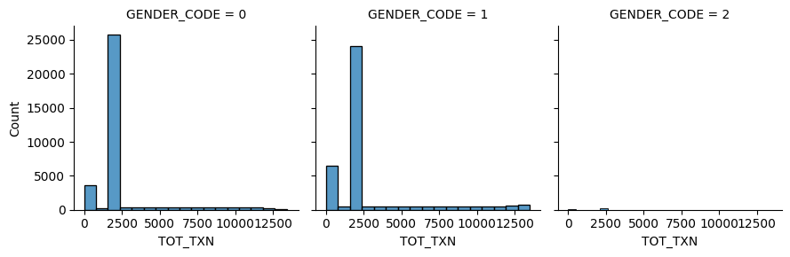

```python
multigraf(df, 'GENDER_CODE','TOT_TXN')
```

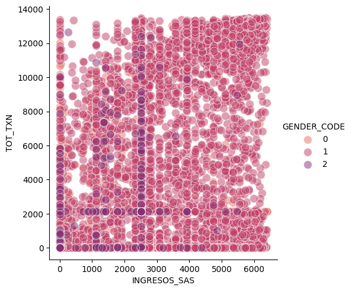

```python
dispersion(df, 'GENDER_CODE','INGRESOS_SAS','TOT_TXN')
```

## Normalización de la data.

```python
datNorm = normaData(df)

datNorm.describe().T
```

|  | count | mean | std | min | 25% | 50% | 75% | max |
| --- | --- | --- | --- | --- | --- | --- | --- | --- |
| PARTY_TYPE_DESC | 72164.0 | 0.028380 | 0.166057 | 0.0 | 0.000000 | 0.000000 | 0.000000 | 1.0 |
| GENDER_CODE | 72164.0 | 0.267377 | 0.253885 | 0.0 | 0.000000 | 0.500000 | 0.500000 | 1.0 |
| INGRESOS_SAS | 72164.0 | 0.399846 | 0.157303 | 0.0 | 0.393532 | 0.393532 | 0.393532 | 1.0 |
| STREET_STATE_NAME | 72164.0 | 0.479286 | 0.282473 | 0.0 | 0.300000 | 0.466667 | 0.666667 | 1.0 |
| STREET_STATE_CODE | 72164.0 | 0.294936 | 0.260741 | 0.0 | 0.111120 | 0.131322 | 0.525257 | 1.0 |
| OCCUPATION_DESC | 72164.0 | 0.201957 | 0.142321 | 0.0 | 0.125000 | 0.125000 | 0.375000 | 1.0 |
| INDUSTRY_CODE | 72164.0 | 0.204568 | 0.353031 | 0.0 | 0.001010 | 0.001010 | 0.438889 | 1.0 |
| TOT_TXN | 72164.0 | 0.201515 | 0.196850 | 0.0 | 0.157454 | 0.157454 | 0.157454 | 1.0 |
| NO_TXN | 72164.0 | 0.001986 | 0.006033 | 0.0 | 0.000156 | 0.000313 | 0.002033 | 1.0 |
| TOT_CR | 72164.0 | 0.149771 | 0.201447 | 0.0 | 0.092594 | 0.092594 | 0.092594 | 1.0 |
| TOT_DB | 72164.0 | 0.020017 | 0.113282 | 0.0 | 0.000000 | 0.000000 | 0.000000 | 1.0 |
| TOT_EFE | 72164.0 | 0.000183 | 0.004993 | 0.0 | 0.000000 | 0.000000 | 0.000039 | 1.0 |
| TOT_ELE | 72164.0 | 0.178167 | 0.107134 | 0.0 | 0.165655 | 0.165655 | 0.165655 | 1.0 |
| ORIGEN_FONDOS | 72164.0 | 0.591835 | 0.237613 | 0.0 | 0.534265 | 0.621662 | 0.682009 | 1.0 |

# Modelos o metodologías utilizadas.

#### Una vez normalizada la información, se realiza la creación del Modelo utilizando Isolation Forest de sklearn. Utilizamos IsolationForest ya que es una técnica de detección de anomalías que identifica directamente las anomalías, a diferencia de algoritmos como "Support vector machine (SVM)", ya que es incapaz de manejar conjuntos de datos atípicos en los que hay un gran número de disparidades entre clases.

- Se selecciona una variable (feature) de forma aleatoria.
- Luego, el conjunto de datos se divide aleatoriamente en función de esta variable para obtener dos subconjuntos de datos.
- Las dos etapas anteriores se repiten hasta aislar un dato.

#### Se asigna una puntuación de anomalía a cada hoja de un árbol, y esta puntuación de anomalía se promedia sobre todos los árboles que se han construido de forma recursiva, para obtener un resultado final. Se pueden ajustar los parámetros como el número de árboles o la proporción de anomalías que hay que considerar para que el resultado sea más preciso.